# Problem definition:

1899. 'Shin Black Spicy Pot-au-feu Flavor Premium Noodle Soup'

1900. 'Shin Bowl'

1901. 'Shin Bowl (New)'

1902. 'Shin Cup'

1903. 'Shin Noodle Soup'

1904. 'Shin Ramyun'

1905. 'Shin Ramyun Black'

1906. 'Shin Ramyun Black Onion'

1907. 'Shin Ramyun Black Spicy Beef'

1908. 'Shin Ramyun Cup'

1909. 'Shin Ramyun Noodle Soup (New Edition)'

1910. 'Shin Ramyun Noodle Spicy Mushroom'

1911. 'Shin Ramyun Shrimp'

1912. 'Shin Toyama Black Ramen'

1913. 'Shinshu Miso Ramen'

1914. 'Shio'

1915. 'Shio Ramen Seafood Mild'

1916. 'Shio Yakisoba'

1917. 'Shiroi Chikara Mochi Udon'

1918. 'Shitake Mushroom Vernicalli'

1919. 'Shokuh Kitsune Udon'

1920. 'Shoop Instant Noodles BBQ Flavour'

1921. 'Shoop Instant Noodles Bombay Biryani Flavour'

1922. 'Shoop Instant Noodles Chicken Flavour'

1923. 'Shoop Instant Noodles Masala Flavour'

1924. 'Shoop Instant Noodles Spicy Lemon Flavour'

1925. 'Shoyu'

1926. 'Shoyu Noodle'

1927. 'Shrimp'

1928. 'Shrimp "Tom Yum" Instant Nudelsuppe'

1929. 'Shrimp (TOM YUM)'

1930. 'Shrimp Creamy Tom Yum'

1931. 'Shrimp Fish'

1932. 'Shrimp Flavor'

1933. 'Shrimp Flavour Oriental Noodles And Soup Mix'

1934. 'Shrimp Tom Yum Flavor'

1935. 'Shrimp Tom Yum Flavour Cup Noodles'

1936. 'Shrimp Udon'

1937. 'Shrimp Wonton'

1938. 'Sibu Instant Kampua Original'

1939. 'Sichuan Hot Pot Sweet Potato Thread'

1940. 'Sichuan Hot Spicy Fish'

1941. 'Sichuan Pepper & Chicken Flavor Noodle'

1942. 'Sichuan Pepper Flavor'

1943. 'Sichuan Pickled Sweet Potato Thread'

1944. 'Sichuan Spices Flavor Noodle'

1945. 'Sichuan Spicy Flavor'

1946. 'Signature Chicken Flavor Instant Noodles'

1947. 'Signature Curry Flavor Instant Noodles'

1948. 'Signature Laksa Singapura Instant Noodles'

1949. 'Signature Spicy Singapore Fried Noodles Instant Noodles'

1950. 'Signature Stir-Fry Original Flavor Instant Noodles'

1951. 'Signature Tom Yum Flavor Instant Noodles'

1952. 'Silk Beef Pho Flavor Instant Rice Fettuccine'

1953. 'Silk Spicy Marinara Instant Rice Fettuccine'

1954. 'Singapore Chilli Crab La Mian'

1955. 'Singapore Curry'

1956. 'Singapore Curry La Mian'

1957. 'Singapore Curry Wholegrain La Mian'

1958. 'Singapore Fish Soup La Mian'

1959. 'Singapore Laksa Curry Soup Bowl'

1960. 'Singapore Laksa La Mian'

1961. 'Singapore Laksa Wholegrain La Mian'

1962. 'Singapore Prawn Soup La Mian'

1963. 'Singapore Soft Noodles'

1964. 'Single Noble Black Bone Chicken Sweet Potato Thread'

1965. 'Single Noble Pickled Radish & Duck'

1966. 'Sir Long Tang Creamy Beef Noodle Soup'

1967. 'Smack Chili'

1968. 'Snack Noodle slightly Hot'

1969. 'Snack Ramyon'

1970. 'Snek Mi Perisa Ayam'

1971. 'Snek Mi Perisa BBQ'

1972. 'Snow Crab Flavour Shio Ramen'

1973. 'Soba'

1974. 'Soba Chili Noodles With Japanese Yakisoba Sauce'

1975. 'Soba Classic Noodles With Japanese Yakisoba Sauce'

1976. 'Soba Curry Noodles With Japanese Yakisoba Sauce'

1977. 'Soba Fried Noodles Chili'

1978. 'Soba Fried Noodles Classic'

1979. 'Soba Fried Noodles Curry'

1980. 'Soba Fried Noodles Teriyaki'

1981. 'Soba Noodles With Mayo Mustard Squirt'

1982. 'Soba Sukiyaki Beef'

1983. 'Soba Teriyaki Noodles With Japanese Yakisoba Sauce'

1984. 'Soba Thai'

1985. 'Soba Yakitori Chicken'

1986. 'Sogokimyun Hot Flavor Noodle Soup'

1987. 'Song Song Kimchi Big Bowl'

1988. 'Soon Veggie Noodle Soup'

1989. 'Sopa Maruchan Sabor a Camaron, Limon y Habanero'

1990. 'Sopa Maruchan Sobar A Camaron'

1991. 'Sopa Nissin Sabor A Camaron Sopa Instantanea Tipo Ramen'

1992. 'Sopa Nissin Sabor A Pollo Sopa Instantanea Tipo Ramen'

1993. 'Sopa Nissin Sabor A Res Instantanea Tipo Ramen'

1994. 'Sopa Nissin Sabor Mariscos, Habanero Y Limon'

1995. 'Sotanghon'

1996. 'Sotanghon Artificial Chicken'

1997. 'Soto Koya Gurih'

1998. 'Soto Koya Jeruk Nipis'

1999. 'Soto Koya Pedasss'

2000. 'Soto Mie'

2001. 'Soup All Natural Hot & Sour'

2002. 'Soup Bowl Chinese Chicken'

2003. 'Soup Bowl South Korean Kimchi'

2004. 'Soup Bowl Vietnamese Pho'

2005. 'Soup Spices Noodle Mee Rempahan Sup'

2006. 'Souper Meal Beef Flavor Minestrone'

2007. 'Souper Meal Chicken Flavor With Vegetable Medley'

2008. 'Souper Meal Chili Picante Chicken With Lime Flavor Ramen Noodle Soup'

2009. 'Souper Meal Picante Shrimp Hot Spicy'

2010. 'Souper Meal Tomato Garlic Shrimp'

2011. 'Soupless Ramen Shallot Teriyaki'

2012. 'Sour & Spicy Flavour'

2013. 'Sour Bamboo Shoot & Beef If Hot Pot Flavor Noodles'

2014. 'Sour Soup & Minced Meat Flavor Chef\'s Grain Naked Oat Noodles'

2015. 'Sour Soup Flavor'

2016. 'Sour Spicy Chicken Tom Yum'

2017. 'South Korean Broad Noodle'

2018. 'South Korean Kimchi Rice Noodle'

2019. 'South Korean Noodle Chicken'

2020. 'South Korean Noodle Kimchi Flavor'

2021. 'South Korean Seafood'

2022. 'South Korean Style Beef'

2023. 'South Korean Style Kim Chee'

2024. 'South Korean Style Pork'

2025. 'South Korean Style Seafood'

2026. 'South Korean Style Spicy Beef'

2027. 'South Korean Style Spicy Pork'

2028. 'South Korean U Dong'

2029. 'Soy Flavor Noodle'

2030. 'Soy Ginger Ramen'

2031. 'Soy Sauce'

2032. 'Soy Sauce Ramen'

2033. 'Soybean Paste'

2034. 'Spa Oh Tarako Spaghetti'

2035. 'Spaghetti'

2036. 'Spaghetti Instant Noodles'

2037. 'Spaghetti Napolitan'

2038. 'Spaghetti Ramen'

2039. 'Spaghetti With Bolognese Sauce'

2040. 'Spaghetti With Mushroom Sauce'

2041. 'Special Baked Mac Style Instant Macaroni'

2042. 'Special Chicken'

2043. 'Special Duck'

2044. 'Special Fried Curly Noodle'

2045. 'Special Fried Curly Noodle (Local)'

2046. 'Special Instant Curly Spaghetti With Yummy Red Sauce'

2047. 'Special Instant Noodles Jjamppong Flavor'

2048. 'Special Instant Pancit Bihon With Kalamansi'

2049. 'Special Instant sopas Chicken Flavor'

2050. 'Speed King Bowl (Prototype)'

2051. 'Spesial Goreng Special'

2052. 'Spesial Rasa Kari Ayam Pedas'

2053. 'Spesial Rasa Soto Ayam'

2054. 'Spice Deli Tantan Men With Cilantro'

2055. 'Spice Seafood'

2056. 'Spicy & Sour Flavor'

2057. 'Spicy Artificial Beef'

2058. 'Spicy Artificial Beef Flavour Instant Noodles With Soup Base'

2059. 'Spicy Artificial Fei Chang Instant Vermicelli (New Recipe)'

2060. 'Spicy Artificial Pork'

2061. 'Spicy Beef'

2062. 'Spicy Beef Flavor Instant Noodle'

2063. 'Spicy Beef Mami Instant Noodle Soup'

2064. 'Spicy Black Pepper'

2065. 'Spicy Braised Pork Flavor'

2066. 'Spicy Chicken'

2067. 'Spicy Chicken Mi Instan Cup'

2068. 'Spicy Chikin Donburi'

2069. 'Spicy Coconut Shrimp'

2070. 'Spicy Fei- Chang Sweet Potato Noodle'

2071. 'Spicy Fish Noodle'

2072. 'Spicy Flavor Tomato Ramen'

2073. 'Spicy Flavour Instant Mifun'

2074. 'Spicy Garlic Ramen'

2075. 'Spicy King Bowl Noodle Spicy Beef'

2076. 'Spicy King Bowl Noodle Spicy Chicken'

2077. 'Spicy King Bowl Noodle Spicy Pork'

2078. 'Spicy King Spicy Beef'

2079. 'Spicy King Spicy Chicken'

2080. 'Spicy King Spicy Pork'

2081. 'Spicy Ramen Noodles'

2082. 'Spicy Seafood'

2083. 'Spicy Seafood Flavor'

2084. 'Spicy Seafood Marinara'

2085. 'Spicy Sesame'

2086. 'Spicy Shrimp Bowl'

2087. 'Spicy Shrimp Cup Noodle'

2088. 'Spicy Shrimp Cup Ramyun'

2089. 'Spicy Shrimp Tom Yam Flavour'

2090. 'Spicy Sichuan Flavor Instant Noodle'

2091. 'Spicy Soup Instant Noodle Beef Flavour'

2092. 'Spicy Sweet & Sour'

2093. 'Spicy Thai'

2094. 'Spicy Tomato Salsa Ramen'

2095. 'Spicy Tomkotsu'

2096. 'Spicy Tonkotsu Noodle Soup'

2097. 'Spinach With Organic Noodles'

2098. 'Spoon-it Beef'

2099. 'Spoon-it Chicken'

2100. 'Spoon-it Creamy Chicken'

2101. 'Spoon-it Rich Hearty Beef Stew'

2102. 'Spoon-it Rich Hearty Savory Chicken'

2103. 'Spring Onion Rice Noodle'

2104. 'Spring Onion Rice Noodle Soup Bowl'

2105. 'Star Popeye Ramyun Snack'

2106. 'Steam Instant Noodles Korean Salt & Rib Soup Flavour'

2107. 'Steam Mushroom Flavor Ramen'

2108. 'Steam Pork Flavour'

2109. 'Steam Seafood Flavor Ramen'

2110. 'Steam Spinach Ramen With Onion'

2111. 'Steam Vegetarian Flavor Noodles'

2112. 'Steam Vermicelli'

2113. 'Steamed Noodle Chinese Herbs'

2114. 'Steamed Noodle Garlic & Sesame Oil'

2115. 'Steamed Noodle Sesame Oil'

2116. 'Stew Buldak Bokkeumtangmyun'

2117. 'Stew Pork'

2118. 'Stewde Chicken Of Mushroom'

2119. 'Stewed Beef Flavor Cooking Noodle'

2120. 'Stewed Duck'

2121. 'Stir Fry Noodles Japanese Style Noodles With Sauce'

2122. 'Stir Rice Vermicelli Indonesian Gado Gado'

2123. 'Stir Rice Vermicelli Singaporean Laksa'

2124. 'Stirfried Kimchi'

2125. 'Straits Kitchen Laksa'

2126. 'Straits Reborn Laksa'

2127. 'Sugo-Men Kyoto Backfat Shoyu Ramen'

2128. 'Sugomen Niigata Seabura Shoyu Ramen'

2129. 'Sugomen Sano Ramen'

2130. 'Sukiyaki Style Noodle Stew'

2131. 'Sun Dried Noodle - Fruity Soy Bean Paste'

2132. 'Sun Dried Noodle Chlorella Powder Noodle With Curry Sauce'

2133. 'Sunbaked Noodles With Sesame Sauce'

2134. 'Sunbaked Noodles With Spicy Sauce'

2135. 'Super Big Ramen Soy Sauce'

2136. 'Super Big Ramen Tonkotsu'

2137. 'Super Bowl Artificial Pickled Chilli Beef'

2138. 'Super Bowl Artificial Spicy Beef'

2139. 'Super Bowl Artificial Stewed Pork Chop'

2140. 'Super Cup Torigawa Shoyu'

2141. 'Super Cup Yochan Ika Yakisoba'

2142. 'Super Low Fat Noodles Chilli Chicken Flavour'

2143. 'Super Noodles Bacon'

2144. 'Super Noodles Barbecue Beef'

2145. 'Super Noodles Chicken'

2146. 'Super Noodles Chicken Mushroom Flavour'

2147. 'Super Noodles Chinese Chow Mein'

2148. 'Super Noodles Low Fat Chicken Herb'

2149. 'Super Noodles Low Fat Sweet Thai Chilli'

2150. 'Super Noodles Mild Curry'

2151. 'Super Noodles Mild Mexican Chilli'

2152. 'Super Noodles Peppered Steak Flavour'

2153. 'Super Noodles Roast Beef & Onion Flavour'

2154. 'Super Noodles Souther Fried Chicken'

2155. 'Super Noodles Sweet & sour'

2156. 'Super Noodles To Go Chinese Space Rib'

2157. 'Super Noodles To Go Curry'

2158. 'Super Rasa Ayam Bawang'

2159. 'Super Tom Yum Shrimp'

2160. 'Supereme Bowl Noodles With Stewed Egg Spicy Flavour'

2161. 'Superior Soup'

2162. 'Superior Soup Instant Noodles (Mfg in Thailand)'

2163. 'Superior Soup Instant Noodles (Mfg in Vietnam)'

2164. 'Superior Soup Instant Rice Vermicelli'

2165. 'Superior Soup Rice Noodle'

2166. 'Supreme Bowl Noodles With Stewed Egg Braised Beef Flavour'

2167. 'Supreme Bowl Noodles With Stewed Egg Sour Beans With Pork Flavour'

2168. 'Supreme Bulalo'

2169. 'Supreme Bulalo Artificial Bone Marrow'

2170. 'Supreme Bulalo Flavor'

2171. 'Supreme Chow Mein Seafood Flavor Instant Stir-Fried Noodles'

2172. 'Supreme Creamy Tom Yum Noodle'

2173. 'Supreme Instant Mami Noodles With Free Crackers'

2174. 'Supreme Jjamppong Korean Style Spicy Seafood Soup'

2175. 'Supreme La Paz Batchoy Beef Garlic'

2176. 'Supreme Pinoy Chicken Instant Noodles'

2177. 'Supreme Seafood Flavor Big Cup'

2178. 'Supreme Sotanghon Artificial Chicken Vermicelli '

2179. 'Supreme Soto'

2180. 'Supreme Special Beef Carne De Vaca'

2181. 'Sutah (SK Version)'

2182. 'Sutah Hot Spicy Beef'

2183. 'Suudon Desse Soy Sauce'

2184. 'Sweet & Sour'

2185. 'Sweet & Spicy'

2186. 'Sweet Potato Instant Noodle Braised Spicy Chitterling Flavor'

2187. 'Sweet Potato Instant Noodle Sout-Hot Flavor'

2188. 'Sweet Potato Noodles With Sesame Paste Sauce'

2189. 'T\'s Restaurant Sura Tanmen'

2190. 'T\'s Restaurant Tantanmen '

2191. 'TVP Curry Chicken'

2192. 'TVP Spicy Beef'

2193. 'TVP Stewed Pork'

2194. 'Tabimen AizuKitakata Gyokai Shoyu Ramen'

2195. 'Tabimen Nagasaki Chanpon'

2196. 'Tachia Dried Noodles - Fried Shallot'

2197. 'Tachia Dried Noodles - Peppery'

2198. 'Tachia Dried Noodles - Rou Zhou Meat Sauce'

2199. 'Tachia Noodles - Hot & Spicy Sauce'

2200. 'Tai Chi Chicken'

2201. 'Taimeiken Yousyoku Yasangatsukutta Omumen'

2202. 'Tainan Noodle Original Sauce'

2203. 'Tainan Yi Mien With Sesame Oil Sauce'

2204. 'Taisho Fried Noodle Sesame Paste Flavour Instant Noodle'

2205. 'Taisho Fried Noodle Yakisoba'

2206. 'Taiwan Dried Noodles With Onion Oil Sauce'

2207. 'Taiwan Style Chow Mein'

2208. 'Tantanmen Spicy Sesame (Mild)'

2209. 'Tanuki Soba'

2210. 'Taste Of Asia Mi Goreng Rasa Bulgogi Ala Korea'

2211. 'Taste Of Asia Mi Kuah Rasa Tom Yum Ala Thailand'

2212. 'Taste Of Malaysia Penang Asam Laksa Fried Instant Noodle'

2213. 'Taste Of Malaysia Penang Asam Laksa Ramen'

2214. 'Taste Of Malaysia Penang Hokkien Mee Fried Instant Noodle'

2215. 'Taste Of Malaysia Penang Hokkien Mee Ramen'

2216. 'Taste Of Malaysia Penang White Curry Fried Instant Noodle'

2217. 'Taste Of Malaysia Penang White Curry Ramen'

2218. 'Taste Sensation Instant Noodles Curry Flavour'

2219. 'Tasty Mushroom'

2220. 'Tempura Soba'

2221. 'Tempura Udon'

2222. 'Tempura Udon Flavor Cup Ramyun'

2223. 'Tenobe Somen'

2224. 'Teriyaki Noodle'

2225. 'Teumsae Ramyun'

2226. 'Thai Ginger Rice Noodle'

2227. 'Thai Tom Yam Flavour'

2228. 'Thailand Green Curry Instant Noodle'

2229. 'The Nation\'s Noodle Beef & Tomato Flavour'

2230. 'The Original Spicy Stir-Fried Noodles'

2231. 'Thin Noodles - Sesame Oil'

2232. 'Three Fresh Delicacies Instant Noodle'

2233. 'Tiny Noodle With Oyster Flavor'

2234. 'Tofu & Miso'

2235. 'Tofu Udon Dosirak'

2236. 'Tohokuno Aji Yonezawa Ramen'

2237. 'Tokushima Ramen'

2238. 'Tokyo Shoyu Ramen'

2239. 'Tokyo Tokunou Gyokai Tonkotsu'

2240. 'Tom Klong'

2241. 'Tom Yam Flavour Instant Noodles'

2242. 'Tom Yam Instant Noodles'

2243. 'Tom Yam Instant soup Noodle'

2244. 'Tom Yam Koong Rice Vermicelli'

2245. 'Tom Yam Prawn'

2246. 'Tom Yam Ramen Pork'

2247. 'Tom Yam Soup Instant Noodle'

2248. 'Tom Yum'

2249. 'Tom Yum Chili Flavor'

2250. 'Tom Yum Goong Flavour Instant Noodle'

2251. 'Tom Yum Rice Noodles'

2252. 'Tom Yum Seafood Creamy'

2253. 'Tom Yum Shrimp'

2254. 'Tom Yum Shrimp Cream Soup'

2255. 'Tom Yum Shrimp Creamy Flavour Instant Noodles'

2256. 'Tom Yum Shrimp Flavour'

2257. 'Tom Yum Shrimp Noodle'

2258. 'Tom Yum Shrimp Rice Stick'

2259. 'Tomato'

2260. 'Tomato & Basil Shio Ramen'

2261. 'Tomato Beef Brisket Flavor Purple Potato Noodle'

2262. 'Tomato Sauce Instant Noodle'

2263. 'Tomato Seafood Rice Noodle'

2264. 'Tomato Vegetables'

2265. 'Tonkotsu'

2266. 'Tonkotsu Ramen'

2267. 'Tonkotsu Ramen Artificially Flavored Tonkotsu White Chicken Broth'

2268. 'Tonkotsu Ramen MEGA Dragon'

2269. 'Tonkotsu-Shoyu Rich Pork Flavor Ramen'

2270. 'Tony\'s Doner Kebab'

2271. 'Toona Paste Noodle'

2272. 'Top Ramen Atta Nooldes Masala'

2273. 'Top Ramen Beef'

2274. 'Top Ramen Chicken'

2275. 'Top Ramen Chicken Flavor Ramen Noodle Soup (New Packaging)'

2276. 'Top Ramen Chili'

2277. 'Top Ramen Creamy Chicken'

2278. 'Top Ramen Cucharealo Habanero Shrimp'

2279. 'Top Ramen Cucharealo Picante Chicken'

2280. 'Top Ramen Cucharealo Tomato Chicken'

2281. 'Top Ramen Oriental'

2282. 'Top Ramen Picante Beef'

2283. 'Top Ramen Short Cuts Beef'

2284. 'Top Ramen Short Cuts Chicken'

2285. 'Top Ramen Short Cuts Lime Chili'

2286. 'Top Ramen Short Cuts Roast Chicken'

2287. 'Top Ramen Shrimp'

2288. 'Top Ramen Super Noodles Tomato'

2289. 'Traditional Shallot & Onion Oil Noodle'

2290. 'Traveller\'s Choice Indian Tikka Masala Flavour'

2291. 'Traveller\'s Choice Thai Red Curry Flavour Instant Noodles'

2292. 'Tteokgukmyun'

2293. 'Tu Quy Pork'

2294. 'Tu Quy Sour Spicy Shrimp'

2295. 'Tu Quy Spicy Beef'

2296. 'Tu quy Chicken'

2297. 'Tuna Flavor Ramen'

2298. 'Tuna With Shallot Flavor Noodle'

2299. 'U-Dong'

2300. 'U.F.O. Yakiosoba'

2301. 'UFO Yakisoba With Wasabi Mayonnaise'

2302. 'Udon'

2303. 'Udon '

2304. 'Udon Beef'

2305. 'Udon Chicken'

2306. 'Udon Crab'

2307. 'Udon Garlic Teriyaki'

2308. 'Udon Hot & Spicy'

2309. 'Udon Japanese Style Fresh Noodle'

2310. 'Udon Japanese Style Noodles With Soup Base Hot & Sour Flavor'

2311. 'Udon Japanese Style Pre-Cooked Noodles With Soup Beef Flavor'

2312. 'Udon Japanese Style Pre-Cooked Noodles With Soup Chicken Flavor'

2313. 'Udon Japanese Style Precooked Noodles With Soup Hot & Spicy Flavor'

2314. 'Udon Miso Stew'

2315. 'Udon Mushroom'

2316. 'Udon Noodle Soup Oriental'

2317. 'Udon Shrimp'

2318. 'Ultraman Instant Noodle Pork Flavour'

2319. 'Umami Ramen'

2320. 'Unif-100 Instant Noodles Artificial Tart Beef Flavor'

2321. 'Unif-100 Pickled Cayenne Flavor Beef Ramen'

2322. 'Vegan Chilli With Sesame Sauce'

2323. 'Vegan Pad Thai Noodle Soup'

2324. 'VegeMee Vegetarian Flavour'

2325. 'Vegetable'

2326. 'Vegetable Atta Noodles Masala'

2327. 'Vegetable Beef'

2328. 'Vegetable Flavour Instant Noodles'

2329. 'Vegetable Flavour Noodles With Vegetables'

2330. 'Vegetable Instant Noodle soup'

2331. 'Vegetarian'

2332. 'Vegetarian Flavor'

2333. 'Vegetarian Flavour Ramen Noodles'

2334. 'Vegetarian Fried Noodles (Mie Goreng)'

2335. 'Vegetarian Herbal Noodle'

2336. 'Vegetarian Instant Cup Noodle Tofu & Shiitake Flavour'

2337. 'Vegetarian Instant Noodles Shiitake Flavour'

2338. 'Vegetarian Instant Noodles Tom Yum Flavour'

2339. 'Vegetarian Penang Laksa'

2340. 'Vegetarian Penang Laksa Instant Bowl Noodles'

2341. 'Vegetarian Penang White Curry'

2342. 'Vegetarian Rice Noodles'

2343. 'Vegetarian Tom Yum'

2344. 'Veggie King Buddha Jump Instant Noodles'

2345. 'Veggie Noodle Baby Grass Noodle With Toona Sauce'

2346. 'Veggie Noodle Black Sesame Noodle'

2347. 'Veggie Noodle Carrot Noodle With Original Sauce'

2348. 'Veggie Noodle Tomato Noodle With Vine Ripened Tomato Sauce'

2349. 'Veggie World Vegetarian Braised Beef Instant Noodles'

2350. 'Vermicelli With Pork'

2351. 'Viet Cuisine Bun Rieu Cua Sour Crab Soup Instant Rice Vermicelli'

2352. 'Viet Rice Noodles Chicken'

2353. 'Vietnamese Chicken Coriander Flavour Vermicelli'

2354. 'Volcano Curry Kkokkomyun'

2355. 'Volcano Spicy Pork Noodle'

2356. 'Wantan Men'

2357. 'Warrior Fighting Shrimp'

2358. 'Wei Wei A Instant Noodles Chicken Flavor'

2359. 'Wei Wei A Instant Noodles Hot Beef Flavour'

2360. 'What’s That? Leisure Meatballs Chicken Flavor'

2361. 'What’s That? Leisure Meatballs Spicy Chicken Flavor'

2362. 'Wheat Gluten Stewed Duck Flavoured'

2363. 'White Curry Noodle'

2364. 'White Curry Noodle More Spicy'

2365. 'Wonton Noodles Beef Flavour'

2366. 'X-Press Flavour Of Pizza In Noodles Proprietary Food'

2367. 'XO Sauce'

2368. 'XO Sauce Noodle'

2369. 'XO Scallops Sauce Dry Noodles'

2370. 'Xi Gon Satay Onion Flavor'

2371. 'Xtra Big Chilimansi Pancit Canton'

2372. 'Xtra Big Kalamansi Pancit Canton'

2373. 'Xtra Big Original Pancit Canton'

2374. 'Yaki-Udon Mild Spicy Sauce'

2375. 'Yaki-Udon Roast Soy Sauce'

2376. 'Yakibuta Ramen'

2377. 'Yakisoba'

2378. 'Yakisoba Beef Taco Flavor'

2379. 'Yakisoba Cheddar Cheese'

2380. 'Yakisoba Chicken'

2381. 'Yakisoba Four Cheese'

2382. 'Yakisoba Jalapeno Cheddar'

2383. 'Yakisoba Japanese Style Noodle'

2384. 'Yakisoba Noodle'

2385. 'Yakisoba Noodles Karashi'

2386. 'Yakisoba Roast chicken'

2387. 'Yakisoba Savory Soy Sauce'

2388. 'Yakisoba Shrimp'

2389. 'Yakisoba Spicy Chicken'

2390. 'Yakisoba Spicy Vegetable'

2391. 'Yakisoba Sweet & Sour Chicken'

2392. 'Yakisoba Teriyaki Beef'

2393. 'Yakisoba Tomato Basil'

2394. 'Yakisoba With Mayonnaise/Mustard Packet'

2395. 'Yellow Buckwheat'

2396. 'Yeul Hot Taste'

2397. 'Yeul Ramyun'

2398. 'Yokohama Tonkotsu Shoyu'

2399. 'Yokohama Walker Iekei Ramen'

2400. 'Yomise No Yakisoba Karashi Mentaiko Flavor'

2401. 'Yomise No Yakisoba Shiodare Flavor With Black Pepper Mayonnaise'

2402. 'Yukgaejang Beef Ramyun'

2403. 'Yummy Spicy Rice Soup With Seafood'

2404. 'Yuzu Sesame Sauce Udon'

2405. 'Zan Vegetarian Instant Noodle Series Shiitake Mushroom Flavour'

2406. 'Zha Wang ((Jjawang) Noodles With Chajang Sauce'

2407. 'Zurek'

2408. 'Zzaldduck Buldak Bokkeummyun Snack'

2409. 'chicken'

2410. 'dried Mix Noodles Soya Bean Paste'

2411. 'spicy Pad Thai Instant Noodles & Sauce'

2412. 'ДОШИРАК (Dosirac) Beef Flavor'

2413. '三養라면 (Samyang Ramyun) (South Korean Version)'

1. ''

2. 'Bar'

3. 'Bowl'

4. 'Box'

5. 'Can'

6. 'Cup'

7. 'Pack'

8. 'Tray'

1. 'Australia'

2. 'Bangladesh'

3. 'Brazil'

4. 'Cambodia'

5. 'Canada'

6. 'China'

7. 'Colombia'

8. 'Dubai'

9. 'Estonia'

10. 'Fiji'

11. 'Finland'

12. 'Germany'

13. 'Ghana'

14. 'Holland'

15. 'Hong Kong'

16. 'Hungary'

17. 'India'

18. 'Indonesia'

19. 'Japan'

20. 'Malaysia'

21. 'Mexico'

22. 'Myanmar'

23. 'Nepal'

24. 'Netherlands'

25. 'Nigeria'

26. 'Pakistan'

27. 'Philippines'

28. 'Poland'

29. 'Sarawak'

30. 'Singapore'

31. 'South Korea'

32. 'Sweden'

33. 'Taiwan'

34. 'Thailand'

35. 'UK'

36. 'USA'

37. 'United States'

38. 'Vietnam'

1. '0'

2. '0.1'

3. '0.25'

4. '0.5'

5. '0.75'

6. '0.9'

7. '1'

8. '1.1'

9. '1.25'

10. '1.5'

11. '1.75'

12. '1.8'

13. '2'

14. '2.1'

15. '2.125'

16. '2.25'

17. '2.3'

18. '2.5'

19. '2.75'

20. '2.8'

21. '2.85'

22. '2.9'

23. '3'

24. '3.0'

25. '3.00'

26. '3.1'

27. '3.125'

28. '3.2'

29. '3.25'

30. '3.3'

31. '3.4'

32. '3.5'

33. '3.50'

34. '3.6'

35. '3.65'

36. '3.7'

37. '3.75'

38. '3.8'

39. '4'

40. '4.0'

41. '4.00'

42. '4.125'

43. '4.25'

44. '4.3'

45. '4.5'

46. '4.50'

47. '4.75'

48. '5'

49. '5.0'

50. '5.00'

51. 'Unrated'

1. ''

2. '\n'

3. '2012 #1'

4. '2012 #10'

5. '2012 #2'

6. '2012 #3'

7. '2012 #4'

8. '2012 #5'

9. '2012 #6'

10. '2012 #7'

11. '2012 #9'

12. '2013 #1'

13. '2013 #10'

14. '2013 #2'

15. '2013 #3'

16. '2013 #4'

17. '2013 #6'

18. '2013 #9'

19. '2014 #1'

20. '2014 #10'

21. '2014 #4'

22. '2014 #5'

23. '2014 #6'

24. '2014 #7'

25. '2014 #8'

26. '2014 #9'

27. '2015 #1'

28. '2015 #10'

29. '2015 #4'

30. '2015 #6'

31. '2015 #7'

32. '2015 #8'

33. '2015 #9'

34. '2016 #1'

35. '2016 #10'

36. '2016 #5'

37. '2016 #7'

38. '2016 #8'

39. '2016 #9'

```r
### Cleaning Stars column

# Since Stars column is the only feature which is numeric, we need to convert its data type from factor to numeric.

ramen$Stars = as.numeric(paste(ramen$Stars))
str(ramen)
```

```
'data.frame':	2580 obs. of  7 variables:
 $ Review..: int  2580 2579 2578 2577 2576 2575 2574 2573 2572 2571 ...
 $ Brand   : Factor w/ 355 levels "1 To 3 Noodles",..: 191 120 193 337 39 250 8 110 234 121 ...
 $ Variety : Factor w/ 2413 levels "\"A\" Series Artificial Chicken",..: 2190 1444 455 710 1955 1109 2054 1371 812 2230 ...
 $ Style   : Factor w/ 8 levels "","Bar","Bowl",..: 6 7 6 7 7 7 6 8 7 7 ...
 $ Country : Factor w/ 38 levels "Australia","Bangladesh",..: 19 33 36 33 17 31 19 19 19 30 ...
 $ Stars   : num  3.75 1 2.25 2.75 3.75 4.75 4 3.75 0.25 2.5 ...
 $ Top.Ten : Factor w/ 39 levels "","\n","2012 #1",..: 1 1 1 1 1 1 1 1 1 1 ...
```

```r
### Cleaning Style column

# Change the data type from character to factor
ramen$Style <- factor(ramen$Style)

# See the levels in Style (before)
levels(ramen$Style)

# Dealing with "" in Style, to assign with "NA"
ramen$Style[ramen$Style == ""] <- "NA"

# See the levels in Style (after)
levels(ramen$Style)

# Remove NA in Style, and other features, but exclude Top.Ten
ramen <- na.omit(ramen, c("Review..", "Brand", "Variety", "Style", "Country","Stars"))

# Drop unused level - NA
# ramen$Style <- droplevels(ramen$Style)
ramen <- droplevels(ramen)

# See the levels in Style after dropping NA
levels(ramen$Style)

# Structure of the dataset after removing records with missing data (but exclude Top.Ten)
str(ramen)
```

1. ''

2. 'Bar'

3. 'Bowl'

4. 'Box'

5. 'Can'

6. 'Cup'

7. 'Pack'

8. 'Tray'

1. ''

2. 'Bar'

3. 'Bowl'

4. 'Box'

5. 'Can'

6. 'Cup'

7. 'Pack'

8. 'Tray'

1. 'Bar'

2. 'Bowl'

3. 'Box'

4. 'Can'

5. 'Cup'

6. 'Pack'

7. 'Tray'

```
'data.frame':	2575 obs. of  7 variables:
 $ Review..: int  2580 2579 2578 2577 2576 2575 2574 2573 2572 2571 ...
 $ Brand   : Factor w/ 355 levels "1 To 3 Noodles",..: 191 120 193 337 39 250 8 110 234 121 ...
 $ Variety : Factor w/ 2408 levels "\"A\" Series Artificial Chicken",..: 2185 1442 454 708 1950 1107 2049 1369 810 2225 ...
 $ Style   : Factor w/ 7 levels "Bar","Bowl","Box",..: 5 6 5 6 6 6 5 7 6 6 ...
 $ Country : Factor w/ 38 levels "Australia","Bangladesh",..: 19 33 36 33 17 31 19 19 19 30 ...
 $ Stars   : num  3.75 1 2.25 2.75 3.75 4.75 4 3.75 0.25 2.5 ...
 $ Top.Ten : Factor w/ 39 levels "","\n","2012 #1",..: 1 1 1 1 1 1 1 1 1 1 ...
 - attr(*, "na.action")= 'omit' Named int  33 123 994 2153 2443
  ..- attr(*, "names")= chr  "33" "123" "994" "2153" ...
```

```r
### Cleaning Top.Ten column Part 1

# Change the data type from character to factor
ramen$Top.Ten <- factor(ramen$Top.Ten)

# Dealing with "\n" in Top.Ten, to assign with ""
ramen$Top.Ten[ramen$Top.Ten == "\n"] <- "NA"

# Dealing with "" in Top.Ten, to assign with "NA"
ramen$Top.Ten[ramen$Top.Ten == ""] <- "NA"

# Read the first 6 observations
head(ramen)
```

| Review.. | Brand | Variety | Style | Country | Stars | Top.Ten |
| --- | --- | --- | --- | --- | --- | --- |
| 2580 | New Touch | T's Restaurant Tantanmen | Cup | Japan | 3.75 | NA |
| 2579 | Just Way | Noodles Spicy Hot Sesame Spicy Hot Sesame Guan-miao Noodles | Pack | Taiwan | 1.00 | NA |
| 2578 | Nissin | Cup Noodles Chicken Vegetable | Cup | USA | 2.25 | NA |
| 2577 | Wei Lih | GGE Ramen Snack Tomato Flavor | Pack | Taiwan | 2.75 | NA |
| 2576 | Ching's Secret | Singapore Curry | Pack | India | 3.75 | NA |
| 2575 | Samyang Foods | Kimchi song Song Ramen | Pack | South Korea | 4.75 | NA |

```r
### Cleaning Top.Ten column Part 2

# Check levels before dropping the levels "" and "\n"
levels(ramen$Top.Ten)

# Drop "" and and "\n" levels
ramen$Top.Ten <- droplevels(ramen$Top.Ten)

# Check levels again
levels(ramen$Top.Ten)

# Structure of the dataset after dropping the level
str(ramen)
```

1. ''

2. '\n'

3. '2012 #1'

4. '2012 #10'

5. '2012 #2'

6. '2012 #3'

7. '2012 #4'

8. '2012 #5'

9. '2012 #6'

10. '2012 #7'

11. '2012 #9'

12. '2013 #1'

13. '2013 #10'

14. '2013 #2'

15. '2013 #3'

16. '2013 #4'

17. '2013 #6'

18. '2013 #9'

19. '2014 #1'

20. '2014 #10'

21. '2014 #4'

22. '2014 #5'

23. '2014 #6'

24. '2014 #7'

25. '2014 #8'

26. '2014 #9'

27. '2015 #1'

28. '2015 #10'

29. '2015 #4'

30. '2015 #6'

31. '2015 #7'

32. '2015 #8'

33. '2015 #9'

34. '2016 #1'

35. '2016 #10'

36. '2016 #5'

37. '2016 #7'

38. '2016 #8'

39. '2016 #9'

1. '2012 #1'

2. '2012 #10'

3. '2012 #2'

4. '2012 #3'

5. '2012 #4'

6. '2012 #5'

7. '2012 #6'

8. '2012 #7'

9. '2012 #9'

10. '2013 #1'

11. '2013 #10'

12. '2013 #2'

13. '2013 #3'

14. '2013 #4'

15. '2013 #6'

16. '2013 #9'

17. '2014 #1'

18. '2014 #10'

19. '2014 #4'

20. '2014 #5'

21. '2014 #6'

22. '2014 #7'

23. '2014 #8'

24. '2014 #9'

25. '2015 #1'

26. '2015 #10'

27. '2015 #4'

28. '2015 #6'

29. '2015 #7'

30. '2015 #8'

31. '2015 #9'

32. '2016 #1'

33. '2016 #10'

34. '2016 #5'

35. '2016 #7'

36. '2016 #8'

37. '2016 #9'

```
'data.frame':	2575 obs. of  7 variables:
 $ Review..: int  2580 2579 2578 2577 2576 2575 2574 2573 2572 2571 ...
 $ Brand   : Factor w/ 355 levels "1 To 3 Noodles",..: 191 120 193 337 39 250 8 110 234 121 ...
 $ Variety : Factor w/ 2408 levels "\"A\" Series Artificial Chicken",..: 2185 1442 454 708 1950 1107 2049 1369 810 2225 ...
 $ Style   : Factor w/ 7 levels "Bar","Bowl","Box",..: 5 6 5 6 6 6 5 7 6 6 ...
 $ Country : Factor w/ 38 levels "Australia","Bangladesh",..: 19 33 36 33 17 31 19 19 19 30 ...
 $ Stars   : num  3.75 1 2.25 2.75 3.75 4.75 4 3.75 0.25 2.5 ...
 $ Top.Ten : Factor w/ 37 levels "2012 #1","2012 #10",..: NA NA NA NA NA NA NA NA NA NA ...
 - attr(*, "na.action")= 'omit' Named int  33 123 994 2153 2443
  ..- attr(*, "names")= chr  "33" "123" "994" "2153" ...
```

```r
### Cleaning Top.Ten column Part 3

# Replace NA with "None", and include "None" into factor levels
ramen[] <- lapply(ramen, function(x){
  # check if you have a factor first:
  if(!is.factor(x)) return(x)
  # otherwise include NAs into factor levels and change factor levels:
  x <- factor(x, exclude=NULL)
  levels(x)[is.na(levels(x))] <- "None"
  return(x)
})

# Check levels again
levels(ramen$Top.Ten)

# Structure of the dataset after including "None" into factor level
str(ramen)

# View first 6 observations after cleaning Top.Ten
head(ramen)
```

1. '2012 #1'

2. '2012 #10'

3. '2012 #2'

4. '2012 #3'

5. '2012 #4'

6. '2012 #5'

7. '2012 #6'

8. '2012 #7'

9. '2012 #9'

10. '2013 #1'

11. '2013 #10'

12. '2013 #2'

13. '2013 #3'

14. '2013 #4'

15. '2013 #6'

16. '2013 #9'

17. '2014 #1'

18. '2014 #10'

19. '2014 #4'

20. '2014 #5'

21. '2014 #6'

22. '2014 #7'

23. '2014 #8'

24. '2014 #9'

25. '2015 #1'

26. '2015 #10'

27. '2015 #4'

28. '2015 #6'

29. '2015 #7'

30. '2015 #8'

31. '2015 #9'

32. '2016 #1'

33. '2016 #10'

34. '2016 #5'

35. '2016 #7'

36. '2016 #8'

37. '2016 #9'

38. 'None'

```
'data.frame':	2575 obs. of  7 variables:
 $ Review..: int  2580 2579 2578 2577 2576 2575 2574 2573 2572 2571 ...
 $ Brand   : Factor w/ 355 levels "1 To 3 Noodles",..: 191 120 193 337 39 250 8 110 234 121 ...
 $ Variety : Factor w/ 2408 levels "\"A\" Series Artificial Chicken",..: 2185 1442 454 708 1950 1107 2049 1369 810 2225 ...
 $ Style   : Factor w/ 7 levels "Bar","Bowl","Box",..: 5 6 5 6 6 6 5 7 6 6 ...
 $ Country : Factor w/ 38 levels "Australia","Bangladesh",..: 19 33 36 33 17 31 19 19 19 30 ...
 $ Stars   : num  3.75 1 2.25 2.75 3.75 4.75 4 3.75 0.25 2.5 ...
 $ Top.Ten : Factor w/ 38 levels "2012 #1","2012 #10",..: 38 38 38 38 38 38 38 38 38 38 ...
 - attr(*, "na.action")= 'omit' Named int  33 123 994 2153 2443
  ..- attr(*, "names")= chr  "33" "123" "994" "2153" ...
```

| Review.. | Brand | Variety | Style | Country | Stars | Top.Ten |
| --- | --- | --- | --- | --- | --- | --- |
| 2580 | New Touch | T's Restaurant Tantanmen | Cup | Japan | 3.75 | None |
| 2579 | Just Way | Noodles Spicy Hot Sesame Spicy Hot Sesame Guan-miao Noodles | Pack | Taiwan | 1.00 | None |
| 2578 | Nissin | Cup Noodles Chicken Vegetable | Cup | USA | 2.25 | None |
| 2577 | Wei Lih | GGE Ramen Snack Tomato Flavor | Pack | Taiwan | 2.75 | None |
| 2576 | Ching's Secret | Singapore Curry | Pack | India | 3.75 | None |
| 2575 | Samyang Foods | Kimchi song Song Ramen | Pack | South Korea | 4.75 | None |

# Understanding/Visualizing the data

```r
# Summary Statistics in ramen dataset
summary(ramen)
```

```
    Review..           Brand                    Variety      Style
 Min.   :   1.0   Nissin  : 381   Beef              :   7   Bar :   1
 1st Qu.: 646.5   Nongshim:  98   Chicken           :   7   Bowl: 481
 Median :1290.0   Maruchan:  76   Artificial Chicken:   6   Box :   6
 Mean   :1290.2   Mama    :  71   Vegetable         :   6   Can :   1
 3rd Qu.:1934.5   Paldo   :  66   Yakisoba          :   6   Cup : 450
 Max.   :2580.0   Myojo   :  63   Miso Ramen        :   5   Pack:1528
                  (Other) :1820   (Other)           :2538   Tray: 108
        Country         Stars           Top.Ten
 Japan      : 352   Min.   :0.000   None    :2538
 USA        : 323   1st Qu.:3.250   2012 #1 :   1
 South Korea: 307   Median :3.750   2012 #10:   1
 Taiwan     : 223   Mean   :3.655   2012 #2 :   1
 Thailand   : 191   3rd Qu.:4.250   2012 #3 :   1
 China      : 168   Max.   :5.000   2012 #4 :   1
 (Other)    :1011                   (Other) :  32
```

```r
# Count of Brands in desending order
df <- data.frame(table(ramen$Brand))
df[rev(order(df$Freq)),]
```

|  | Var1 | Freq |
| --- | --- | --- |
| 193 | Nissin | 381 |
| 196 | Nongshim | 98 |
| 161 | Maruchan | 76 |
| 158 | Mama | 71 |
| 209 | Paldo | 66 |
| 184 | Myojo | 63 |
| 111 | Indomie | 53 |
| 250 | Samyang Foods | 51 |
| 207 | Ottogi | 45 |
| 331 | Vina Acecook | 34 |
| 154 | Lucky Me! | 34 |
| 330 | Vifon | 33 |
| 156 | Maggi | 30 |
| 160 | Mamee | 29 |
| 163 | Master Kong | 28 |
| 155 | MAMA | 27 |
| 5 | A-Sha Dry Noodle | 26 |
| 333 | Wai Wai | 25 |
| 255 | Sapporo Ichiban | 25 |
| 121 | KOKA | 25 |
| 328 | Ve Wong | 24 |
| 182 | MyKuali | 24 |
| 117 | JML | 23 |
| 249 | Samyang | 19 |
| 135 | Koka | 18 |
| 53 | Doll | 16 |
| 24 | Batchelors | 16 |
| 337 | Wei Lih | 15 |
| 178 | Mr. Noodles | 15 |
| 8 | Acecook | 15 |
| ... | ... | ... |
| 101 | Higashimaru | 1 |
| 100 | Higashi | 1 |
| 92 | Haioreum | 1 |
| 91 | Guava Story | 1 |
| 88 | Good Tto Leu Foods | 1 |
| 86 | Golden Wonder | 1 |
| 81 | Global Inspiration | 1 |
| 76 | GGE | 1 |
| 73 | Fuji Mengyo | 1 |
| 72 | Fu Chang Chinese Noodle Company | 1 |
| 65 | Farmer's Heart | 1 |
| 61 | Econsave | 1 |
| 55 | Dr. McDougall's | 1 |
| 54 | Dongwon | 1 |
| 51 | Daraz | 1 |
| 49 | Daifuku | 1 |
| 48 | Daddy | 1 |
| 47 | Curry Prince | 1 |
| 46 | Crystal Noodle | 1 |
| 42 | Choumama | 1 |
| 41 | ChoripDong | 1 |
| 40 | Chorip Dong | 1 |
| 38 | China Best | 1 |
| 37 | Chikara | 1 |
| 33 | Chaudhary's Wai Wai | 1 |
| 31 | Cap Atoom Bulan | 1 |
| 28 | Boss | 1 |
| 18 | Authentically Asian | 1 |
| 3 | 7 Select/Nissin | 1 |
| 1 | 1 To 3 Noodles | 1 |

The brand most reviewed is Nissin from Japan.

```r
# Extract Nissin ramen details
nissin_data = subset(ramen, Brand == "Nissin")
nissin_data
```

|  | Review.. | Brand | Variety | Style | Country | Stars | Top.Ten |
| --- | --- | --- | --- | --- | --- | --- | --- |
| 3 | 2578 | Nissin | Cup Noodles Chicken Vegetable | Cup | USA | 2.25 | None |
| 14 | 2567 | Nissin | Deka Buto Kimchi Pork Flavor | Bowl | Japan | 4.50 | None |
| 15 | 2566 | Nissin | Demae Ramen Bar Noodle Aka Tonkotsu Flavour Instant Noodle | Pack | Hong Kong | 5.00 | None |
| 21 | 2560 | Nissin | Cup Noodles Laksa Flavour | Cup | Hong Kong | 4.25 | None |
| 28 | 2553 | Nissin | Hakata Ramen Noodle White Tonkotsu | Bowl | Japan | 4.75 | None |
| 32 | 2549 | Nissin | Gekikara Ramen Extra Hot Ramen Goreng | Pack | Indonesia | 4.50 | None |
| 40 | 2541 | Nissin | Cup Noodles Very Veggie Spicy Chicken Flavor Ramen Noodle Soup | Cup | USA | 5.00 | None |
| 42 | 2539 | Nissin | Demae Iccho Tonkotsu Flavour Instant Noodle | Cup | Hong Kong | 3.75 | None |
| 43 | 2538 | Nissin | Cup Noodles Very Veggie Beef Flavor Ramen Noodle Soup | Cup | USA | 5.00 | None |
| 44 | 2537 | Nissin | Cup NoodlesTom Yam Seafood (More Shrimptacular) | Cup | Singapore | 5.00 | None |
| 46 | 2535 | Nissin | Cup Noodles Very Veggie Chicken Flavor Ramen Noodle Soup | Cup | USA | 5.00 | None |
| 49 | 2532 | Nissin | Nippon Onomichi Ramen | Bowl | Japan | 4.75 | None |
| 57 | 2524 | Nissin | Straits Reborn Laksa | Pack | Singapore | 5.00 | None |
| 60 | 2521 | Nissin | Cup Noodles Potato Chips Black Pepper Crab Flavour | Pack | Singapore | 4.50 | None |
| 61 | 2520 | Nissin | Cup Noodles Blacl Pepper Crab Flavour (More Angry Crab) | Cup | Singapore | 5.00 | None |
| 83 | 2498 | Nissin | Demae Ramen Spicy Beef | Pack | Germany | 3.75 | None |
| 84 | 2497 | Nissin | Cup Noodles Spicy | Cup | Germany | 3.75 | None |
| 85 | 2496 | Nissin | Soba Thai | Pack | Germany | 4.50 | None |
| 86 | 2495 | Nissin | Cup Noodles Huhn (Chicken) | Cup | Germany | 3.75 | None |
| 87 | 2494 | Nissin | Demae Ramen Korean Kimchi | Pack | Germany | 3.50 | None |
| 88 | 2493 | Nissin | Cup Noodles Curry | Cup | Germany | 3.75 | None |
| 89 | 2492 | Nissin | Smack Chili | Pack | Hungary | 3.75 | None |
| 90 | 2491 | Nissin | Soba Yakitori Chicken | Cup | Germany | 5.00 | None |
| 91 | 2490 | Nissin | Demae Ramen Garlic Chicken | Pack | Germany | 3.50 | None |
| 92 | 2489 | Nissin | Cup Noodles Ente (Duck) | Cup | Germany | 3.00 | None |
| 93 | 2488 | Nissin | Demae Ramen Thai Tom Yum | Pack | Germany | 3.75 | None |
| 94 | 2487 | Nissin | Soba Sukiyaki Beef | Cup | Germany | 4.50 | None |
| 95 | 2486 | Nissin | Demae Ramen Spicy | Pack | Germany | 3.50 | None |
| 96 | 2485 | Nissin | Cup Noodles Shrimps | Cup | Germany | 3.00 | None |
| 97 | 2484 | Nissin | Demae Ramen Tokyo Soy Sauce | Pack | Germany | 4.00 | None |
| ... | ... | ... | ... | ... | ... | ... | ... |
| 2343 | 238 | Nissin | Chow Noodles Tomato Basil | Bowl | USA | 4.00 | None |
| 2355 | 226 | Nissin | Chow Noodles Cheddar Cheese | Tray | USA | 4.00 | None |
| 2360 | 221 | Nissin | Top Ramen Beef | Pack | USA | 3.75 | None |
| 2372 | 209 | Nissin | Souper Meal Beef Flavor Minestrone | Bowl | USA | 3.00 | None |
| 2385 | 196 | Nissin | Cup Noodles Pani Puri | Cup | India | 1.50 | None |
| 2392 | 189 | Nissin | Cup Noodles Manchurian | Cup | India | 3.00 | None |
| 2398 | 183 | Nissin | Bowl Noodles Hot & Spicy Chicken | Bowl | USA | 2.00 | None |
| 2424 | 157 | Nissin | Sotanghon | Cup | Philippines | 2.00 | None |
| 2427 | 154 | Nissin | Creamy Chicken | Cup | USA | 1.75 | None |
| 2439 | 142 | Nissin | Chow Mein Teriyaki Beef | Tray | USA | 4.50 | None |
| 2444 | 137 | Nissin | Bowl Noodles Rich & Savory Chicken | Bowl | USA | 1.75 | None |
| 2457 | 124 | Nissin | Yakisoba With Mayonnaise/Mustard Packet | Tray | Japan | 5.00 | None |
| 2496 | 85 | Nissin | Demae Ramen Sesame | Pack | Japan | 3.75 | None |
| 2498 | 83 | Nissin | Demae Ramen Spicy Flavor | Pack | Japan | 2.00 | None |
| 2499 | 82 | Nissin | Demae Ramen Miso | Pack | Japan | 2.75 | None |
| 2503 | 78 | Nissin | Demae Ramen Seafood | Pack | Japan | 2.50 | None |
| 2504 | 77 | Nissin | Demae Ramen Prawn | Pack | Japan | 3.25 | None |
| 2507 | 74 | Nissin | Demae Ramen Shoyu | Pack | Japan | 4.00 | None |
| 2508 | 73 | Nissin | Demae Ramen Five Spices Artificial Beef | Pack | Japan | 3.50 | None |
| 2509 | 72 | Nissin | Demae Ramen Tonkatsu Artificial Pork | Pack | Japan | 3.50 | None |
| 2510 | 71 | Nissin | Demae Ramen Satay | Pack | Japan | 2.50 | None |
| 2511 | 70 | Nissin | Demae Ramen XO Sauce Seafood | Pack | Japan | 4.00 | None |
| 2516 | 65 | Nissin | Top Ramen Oriental | Pack | USA | 2.50 | None |
| 2518 | 63 | Nissin | Souper Meal Chicken Flavor With Vegetable Medley | Bowl | Japan | 3.00 | None |
| 2553 | 28 | Nissin | Chikin Ramen | Pack | Japan | 5.00 | None |
| 2554 | 27 | Nissin | Demae Ramen Curry Flavor | Pack | Japan | 4.00 | None |
| 2555 | 26 | Nissin | Soba Noodles With Mayo Mustard Squirt | Pack | Japan | 4.00 | None |
| 2556 | 25 | Nissin | Demae Ramen Spicy Flavor | Pack | Japan | 3.00 | None |
| 2557 | 24 | Nissin | Demae Ramen Spicy Seafood With Chili Pepper | Pack | Japan | 2.00 | None |
| 2558 | 23 | Nissin | Top Ramen Creamy Chicken | Pack | USA | 4.50 | None |

```r
# Count of Style in desending order
df <- data.frame(table(ramen$Style))
df[rev(order(df$Freq)),]
```

|  | Var1 | Freq |
| --- | --- | --- |
| 6 | Pack | 1528 |
| 2 | Bowl | 481 |
| 5 | Cup | 450 |
| 7 | Tray | 108 |
| 3 | Box | 6 |
| 4 | Can | 1 |
| 1 | Bar | 1 |

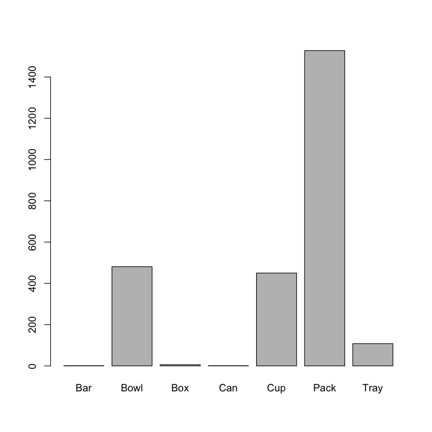

```r
# To find the most common ramen style being reviewed through plot
plot(ramen$Style)
```

More than half of the reviewed styles is Pack.

```r
# https://uc-r.github.io/descriptives_categorical

#To view what ramen styles are with the best reviews (above average scale)
df <- data.frame(table(ramen$Stars, ramen$Style))
df[rev(order(df$Freq)),]
```

|  | Var1 | Var2 | Freq |
| --- | --- | --- | --- |
| 246 | 4 | Pack | 245 |
| 252 | 5 | Pack | 239 |
| 244 | 3.75 | Pack | 212 |
| 240 | 3.5 | Pack | 192 |
| 237 | 3.25 | Pack | 109 |
| 233 | 3 | Pack | 92 |
| 250 | 4.5 | Pack | 87 |
| 248 | 4.25 | Pack | 85 |
| 198 | 3.5 | Cup | 76 |
| 84 | 5 | Bowl | 71 |
| 204 | 4 | Cup | 66 |
| 78 | 4 | Bowl | 65 |
| 72 | 3.5 | Bowl | 63 |
| 202 | 3.75 | Cup | 59 |
| 210 | 5 | Cup | 58 |
| 76 | 3.75 | Bowl | 57 |
| 229 | 2.75 | Pack | 49 |
| 191 | 3 | Cup | 47 |
| 228 | 2.5 | Pack | 39 |
| 251 | 4.75 | Pack | 36 |
| 223 | 2 | Pack | 35 |
| 80 | 4.25 | Bowl | 35 |
| 82 | 4.5 | Bowl | 32 |
| 69 | 3.25 | Bowl | 28 |
| 65 | 3 | Bowl | 27 |
| 195 | 3.25 | Cup | 25 |
| 286 | 3.75 | Tray | 21 |
| 220 | 1.5 | Pack | 21 |
| 217 | 1 | Pack | 19 |
| 83 | 4.75 | Bowl | 19 |
| ... | ... | ... | ... |
| 30 | 3.5 | Bar | 0 |
| 29 | 3.4 | Bar | 0 |
| 28 | 3.3 | Bar | 0 |
| 27 | 3.25 | Bar | 0 |
| 26 | 3.2 | Bar | 0 |
| 25 | 3.125 | Bar | 0 |
| 24 | 3.1 | Bar | 0 |
| 23 | 3 | Bar | 0 |
| 22 | 2.9 | Bar | 0 |
| 21 | 2.85 | Bar | 0 |
| 20 | 2.8 | Bar | 0 |
| 19 | 2.75 | Bar | 0 |
| 18 | 2.5 | Bar | 0 |
| 17 | 2.3 | Bar | 0 |
| 16 | 2.25 | Bar | 0 |
| 15 | 2.125 | Bar | 0 |
| 14 | 2.1 | Bar | 0 |
| 13 | 2 | Bar | 0 |
| 12 | 1.8 | Bar | 0 |
| 11 | 1.75 | Bar | 0 |
| 10 | 1.5 | Bar | 0 |
| 9 | 1.25 | Bar | 0 |
| 8 | 1.1 | Bar | 0 |
| 7 | 1 | Bar | 0 |
| 6 | 0.9 | Bar | 0 |
| 5 | 0.75 | Bar | 0 |
| 4 | 0.5 | Bar | 0 |
| 3 | 0.25 | Bar | 0 |
| 2 | 0.1 | Bar | 0 |
| 1 | 0 | Bar | 0 |

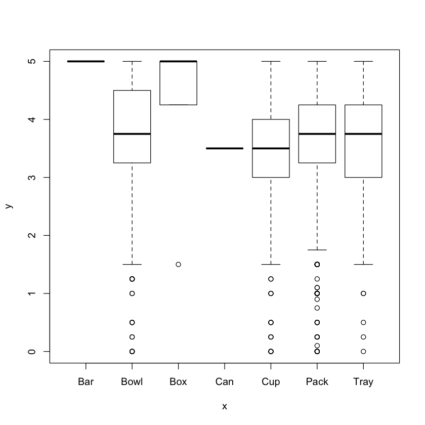

```r
# Seeing trends between 2 categorical data
plot(ramen$Style, ramen$Stars)
```

In conclusion, pack style is more common in Ramen industry.

Box style seems to be also getting very high reviews.

```r
# Extract box ramen details
box_data = subset(ramen, Style == "Box")
box_data
```

|  | Review.. | Brand | Variety | Style | Country | Stars | Top.Ten |
| --- | --- | --- | --- | --- | --- | --- | --- |
| 37 | 2544 | Lipton | Cup-A-Soup Chicken Noodle With White Meat Instant Soup | Box | USA | 1.50 | None |
| 81 | 2500 | The Ramen Rater Select | Supreme Creamy Tom Yum Noodle | Box | Malaysia | 5.00 | None |
| 140 | 2441 | MyKuali | Penang Hokkien Prawn Flavor Noodle | Box | Japan | 5.00 | None |
| 162 | 2419 | MyKuali | Penang Red Tom Yum Goong | Box | Japan | 5.00 | None |
| 204 | 2377 | MyKuali | Penang White Curry Instant Noodle (Japan Version) | Box | Malaysia | 5.00 | None |
| 1472 | 1109 | La Fonte | Spaghetti With Bolognese Sauce | Box | Indonesia | 4.25 | None |

None of the box ramen were in Top Ten, however, they are scoring above 4, except for one ramen which scored 1.5.

The number of reviewed box ramen is also too small.

```r
# Count of Country in desending order
df <- data.frame(table(ramen$Country))
df[rev(order(df$Freq)),]
```

|  | Var1 | Freq |
| --- | --- | --- |
| 19 | Japan | 352 |
| 36 | USA | 323 |
| 31 | South Korea | 307 |
| 33 | Taiwan | 223 |
| 34 | Thailand | 191 |
| 6 | China | 168 |
| 20 | Malaysia | 155 |
| 15 | Hong Kong | 137 |
| 18 | Indonesia | 126 |
| 30 | Singapore | 109 |
| 38 | Vietnam | 108 |
| 35 | UK | 69 |
| 27 | Philippines | 47 |
| 5 | Canada | 41 |
| 17 | India | 31 |
| 12 | Germany | 27 |
| 21 | Mexico | 25 |
| 1 | Australia | 22 |
| 24 | Netherlands | 15 |
| 23 | Nepal | 14 |
| 22 | Myanmar | 14 |
| 26 | Pakistan | 9 |
| 16 | Hungary | 9 |
| 2 | Bangladesh | 7 |
| 7 | Colombia | 6 |
| 4 | Cambodia | 5 |
| 3 | Brazil | 5 |
| 28 | Poland | 4 |
| 14 | Holland | 4 |
| 10 | Fiji | 4 |
| 32 | Sweden | 3 |
| 29 | Sarawak | 3 |
| 11 | Finland | 3 |
| 8 | Dubai | 3 |
| 13 | Ghana | 2 |
| 9 | Estonia | 2 |
| 37 | United States | 1 |
| 25 | Nigeria | 1 |

Most of the reviewed Ramens are from Japan, USA, South Korea, and Taiwan.

```r
# To find the brands under USA
usa_data = subset(ramen, Country == "USA")
usa_data

USA_df <- data.frame(table(usa_data$Brand))
USA_df[rev(order(USA_df$Freq)),]
```

|  | Review.. | Brand | Variety | Style | Country | Stars | Top.Ten |
| --- | --- | --- | --- | --- | --- | --- | --- |
| 3 | 2578 | Nissin | Cup Noodles Chicken Vegetable | Cup | USA | 2.25 | None |
| 12 | 2569 | Yamachan | Yokohama Tonkotsu Shoyu | Pack | USA | 5.00 | None |
| 18 | 2563 | Yamachan | Tokyo Shoyu Ramen | Pack | USA | 5.00 | None |
| 22 | 2559 | Jackpot Teriyaki | Beef Ramen | Pack | USA | 5.00 | None |
| 24 | 2557 | Yamachan | Sapporo Miso Ramen | Pack | USA | 4.75 | None |
| 37 | 2544 | Lipton | Cup-A-Soup Chicken Noodle With White Meat Instant Soup | Box | USA | 1.50 | None |
| 40 | 2541 | Nissin | Cup Noodles Very Veggie Spicy Chicken Flavor Ramen Noodle Soup | Cup | USA | 5.00 | None |
| 43 | 2538 | Nissin | Cup Noodles Very Veggie Beef Flavor Ramen Noodle Soup | Cup | USA | 5.00 | None |
| 46 | 2535 | Nissin | Cup Noodles Very Veggie Chicken Flavor Ramen Noodle Soup | Cup | USA | 5.00 | None |
| 68 | 2513 | Pringles | Nissin Top Ramen Chicken Flavor Potato Crisps | Can | USA | 3.50 | None |
| 111 | 2470 | Myojo | Udon Japanese Style Noodles With Soup Base Hot & Sour Flavor | Pack | USA | 3.75 | None |
| 121 | 2460 | Daifuku | Katsuo Bowl Udon | Bowl | USA | 5.00 | None |
| 150 | 2431 | Dream Kitchen | Udon Japanese Style Fresh Noodle | Bowl | USA | 3.75 | None |
| 155 | 2426 | Dr. McDougall's | Vegan Pad Thai Noodle Soup | Cup | USA | 0.00 | None |
| 169 | 2412 | Shirakiku | Sanukiya Udon Shrimp Flavor | Pack | USA | 3.25 | None |
| 170 | 2411 | Mama Pat's | Chicken Fajita Flavor Instant Ramen Noodles | Pack | USA | 3.75 | None |
| 171 | 2410 | Mama Pat's | Lamb Stew Flavor Instant Ramen Noodles | Pack | USA | 3.75 | None |
| 172 | 2409 | Mama Pat's | Seafood Gumbo Flavor Instant Ramen Noodles | Pack | USA | 3.50 | None |
| 173 | 2408 | Mama Pat's | Chicken Taco Flavor Instant Ramen Noodles | Pack | USA | 3.75 | None |
| 178 | 2403 | Goku-Uma | Yakisoba Japanese Style Noodle | Bowl | USA | 4.75 | None |
| 192 | 2389 | Gefen | Imitation Chicken Flavor | Cup | USA | 4.00 | None |
| 198 | 2383 | Nissin | Cup Noodles Beef Flavor Ramen Noodle Soup (New Recipe) | Cup | USA | 3.50 | None |
| 202 | 2379 | Nissin | Cup Noodles Hot & Spicy Shrimp Flavor Ramen Noodle Soup (New Recipe) | Cup | USA | 2.50 | None |
| 254 | 2327 | Nissin | Cup Noodles Spicy Lime Flavor Ramen Noodle Soup (New Recipe) | Cup | USA | 4.00 | None |
| 266 | 2315 | Goku-Uma | Ramen Noodles Miso Flavor | Bowl | USA | 3.00 | None |
| 283 | 2298 | Nissin | Cup Noodles Spicy Chile Chicken (New Recipe) | Cup | USA | 4.00 | None |
| 304 | 2277 | Goku-Uma | Ramen Noodles Soy Sauce Flavor | Bowl | USA | 3.00 | None |
| 305 | 2276 | Nissin | Cup Noodles With Shrimp Ramen Noodle Soup (New Recipe) | Cup | USA | 3.00 | None |
| 314 | 2267 | Shirakiku | Karami Ramen Spicy Chili Flavour Japanese Style Noodle With Soup Base | Pack | USA | 2.00 | None |
| 319 | 2262 | Dream Kitchen | Curry Flavour Instant Noodles | Cup | USA | 5.00 | None |
| ... | ... | ... | ... | ... | ... | ... | ... |
| 2365 | 216 | Maruchan | Instant Lunch Roast Chicken Flavor | Cup | USA | 2.75 | None |
| 2366 | 215 | Maruchan | Yakisoba Chicken | Tray | USA | 2.00 | None |
| 2367 | 214 | Maruchan | Yakisoba Teriyaki Beef | Tray | USA | 2.00 | None |
| 2368 | 213 | Nongshim | Bowl Noodle Spicy Artificial Lobster | Bowl | USA | 4.00 | None |
| 2369 | 212 | Maruchan | Yakisoba Roast chicken | Tray | USA | 3.75 | None |
| 2372 | 209 | Nissin | Souper Meal Beef Flavor Minestrone | Bowl | USA | 3.00 | None |
| 2374 | 207 | Sapporo Ichiban | Original Flavor | Pack | USA | 3.50 | None |
| 2376 | 205 | Sapporo Ichiban | Beef Flavor | Pack | USA | 4.50 | None |
| 2377 | 204 | Nongshim | Bowl Noodle Spicy Shrimp | Bowl | USA | 2.50 | None |
| 2378 | 203 | Nongshim | Bowl Noodle Hot & Spicy | Bowl | USA | 2.00 | None |
| 2379 | 202 | Nongshim | Bowl Noodle Cabbage Kimchi | Bowl | USA | 3.25 | None |
| 2380 | 201 | Nongshim | Bowl Noodle Beef Ginger | Bowl | USA | 3.50 | None |
| 2381 | 200 | Nongshim | Bowl Noodle Spicy Chicken | Bowl | USA | 4.50 | None |
| 2398 | 183 | Nissin | Bowl Noodles Hot & Spicy Chicken | Bowl | USA | 2.00 | None |
| 2415 | 166 | Koyo | Garlic Pepper | Pack | USA | 3.25 | None |
| 2425 | 156 | Maruchan | Instant Lunch Cajun Style With chili Piquin Shrimp | Cup | USA | 3.00 | None |
| 2427 | 154 | Nissin | Creamy Chicken | Cup | USA | 1.75 | None |
| 2428 | 153 | Sapporo Ichiban | Shrimp Flavor | Cup | USA | 1.75 | None |
| 2439 | 142 | Nissin | Chow Mein Teriyaki Beef | Tray | USA | 4.50 | None |
| 2444 | 137 | Nissin | Bowl Noodles Rich & Savory Chicken | Bowl | USA | 1.75 | None |
| 2473 | 108 | Teriyaki Time | Ramen | Bowl | USA | 2.00 | None |
| 2477 | 104 | Maruchan | Ramen Noodle Soup Chicken | Pack | USA | 2.00 | None |
| 2514 | 67 | Maruchan | Ramen Noodle Soup Lime Chili Shrimp | Pack | USA | 2.00 | None |
| 2515 | 66 | Maruchan | Ramen Noodle Soup Pork | Pack | USA | 4.00 | None |
| 2516 | 65 | Nissin | Top Ramen Oriental | Pack | USA | 2.50 | None |
| 2517 | 64 | Sapporo Ichiban | Chicken Flavor | Pack | USA | 3.50 | None |
| 2547 | 34 | Maruchan | Ramen Noodle Soup Shrimp | Pack | USA | 2.00 | None |
| 2558 | 23 | Nissin | Top Ramen Creamy Chicken | Pack | USA | 4.50 | None |
| 2571 | 10 | Smack | Vegetable Beef | Pack | USA | 1.50 | None |
| 2580 | 1 | Westbrae | Miso Ramen | Pack | USA | 0.50 | None |

|  | Var1 | Freq |
| --- | --- | --- |
| 193 | Nissin | 95 |
| 161 | Maruchan | 51 |
| 196 | Nongshim | 35 |
| 14 | Annie Chun's | 12 |
| 347 | Yamachan | 11 |
| 299 | Thai Kitchen | 10 |
| 255 | Sapporo Ichiban | 10 |
| 277 | Sun Noodle | 7 |
| 137 | Koyo | 7 |
| 292 | Tasty Bite | 6 |
| 184 | Myojo | 6 |
| 312 | Tradition | 5 |
| 244 | Sakura Noodle | 5 |
| 263 | Shirakiku | 4 |
| 159 | Mama Pat's | 4 |
| 83 | Goku-Uma | 4 |
| 80 | Gefen | 4 |
| 70 | Fortune | 4 |
| 57 | Dream Kitchen | 4 |
| 301 | Thai Smile | 3 |
| 300 | Thai Pavilion | 3 |
| 152 | Lotus Foods | 3 |
| 108 | IbuRamen | 3 |
| 236 | Roland | 2 |
| 339 | Westbrae | 1 |
| 317 | US Canning | 1 |
| 295 | Teriyaki Time | 1 |
| 293 | Tayho | 1 |
| 274 | Star Anise Foods | 1 |
| 269 | Snapdragon | 1 |
| ... | ... | ... |
| 32 | CarJEN | 0 |
| 31 | Cap Atoom Bulan | 0 |
| 30 | Campbell's | 0 |
| 29 | CJ CheilJedang | 0 |
| 28 | Boss | 0 |
| 27 | Bonasia | 0 |
| 26 | Bon Go Jang | 0 |
| 25 | Binh Tay | 0 |
| 24 | Batchelors | 0 |
| 23 | Bamee | 0 |
| 22 | Baltix | 0 |
| 21 | Baixiang Noodles | 0 |
| 20 | Baijia | 0 |
| 19 | Azami | 0 |
| 17 | Asian Thai Foods | 0 |
| 16 | Asia Gold | 0 |
| 15 | Aroi | 0 |
| 13 | Amino | 0 |
| 12 | Amianda | 0 |
| 11 | Ajinatori | 0 |
| 10 | Ah Lai | 0 |
| 9 | Adabi | 0 |
| 8 | Acecook | 0 |
| 7 | ABC | 0 |
| 6 | A1 | 0 |
| 5 | A-Sha Dry Noodle | 0 |
| 4 | A-One | 0 |
| 3 | 7 Select/Nissin | 0 |
| 2 | 7 Select | 0 |
| 1 | 1 To 3 Noodles | 0 |

Most of the brands in USA are from Asia.

```r
# Count of Stars in desending order
df <- data.frame(table(ramen$Stars))
df[rev(order(df$Freq)),]
```

|  | Var1 | Freq |
| --- | --- | --- |
| 36 | 4 | 393 |
| 42 | 5 | 386 |
| 34 | 3.75 | 349 |
| 30 | 3.5 | 335 |
| 23 | 3 | 175 |
| 27 | 3.25 | 170 |
| 38 | 4.25 | 143 |
| 40 | 4.5 | 135 |
| 19 | 2.75 | 85 |
| 13 | 2 | 68 |
| 18 | 2.5 | 67 |
| 41 | 4.75 | 64 |
| 10 | 1.5 | 37 |
| 11 | 1.75 | 27 |
| 7 | 1 | 26 |
| 1 | 0 | 26 |
| 16 | 2.25 | 21 |
| 4 | 0.5 | 14 |
| 3 | 0.25 | 11 |
| 9 | 1.25 | 10 |
| 39 | 4.3 | 4 |
| 35 | 3.8 | 3 |
| 37 | 4.125 | 2 |
| 24 | 3.1 | 2 |
| 22 | 2.9 | 2 |
| 20 | 2.8 | 2 |
| 17 | 2.3 | 2 |
| 8 | 1.1 | 2 |
| 33 | 3.7 | 1 |
| 32 | 3.65 | 1 |
| 31 | 3.6 | 1 |
| 29 | 3.4 | 1 |
| 28 | 3.3 | 1 |
| 26 | 3.2 | 1 |
| 25 | 3.125 | 1 |
| 21 | 2.85 | 1 |
| 15 | 2.125 | 1 |
| 14 | 2.1 | 1 |
| 12 | 1.8 | 1 |
| 6 | 0.9 | 1 |
| 5 | 0.75 | 1 |
| 2 | 0.1 | 1 |

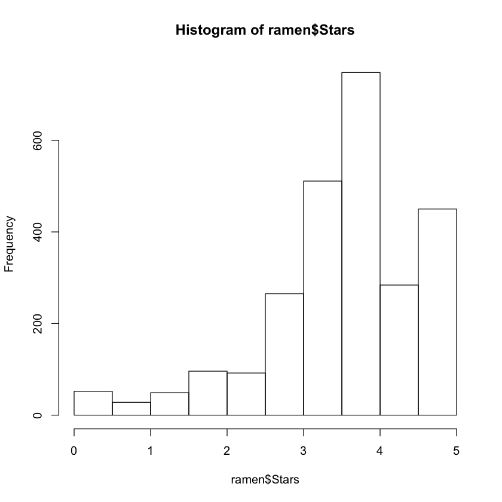

```r
# Histogram of Stars
hist(ramen$Stars)
```

Majority of the reviews are towards "more than average".

```r
# Extract Top Ten ramen details
topten_data = subset(ramen, Top.Ten != "None")
print("No of Top Ten ramen from 2012 to 2016: ")
nrow(topten_data)
topten_data
```

```
[1] "No of Top Ten ramen from 2012 to 2016: "
```

37

|  | Review.. | Brand | Variety | Style | Country | Stars | Top.Ten |
| --- | --- | --- | --- | --- | --- | --- | --- |
| 617 | 1964 | MAMA | Instant Noodles Coconut Milk Flavour | Pack | Myanmar | 5.00 | 2016 #10 |
| 634 | 1947 | Prima Taste | Singapore Laksa Wholegrain La Mian | Pack | Singapore | 5.00 | 2016 #1 |
| 656 | 1925 | Prima | Juzz's Mee Creamy Chicken Flavour | Pack | Singapore | 5.00 | 2016 #8 |
| 674 | 1907 | Prima Taste | Singapore Curry Wholegrain La Mian | Pack | Singapore | 5.00 | 2016 #5 |
| 753 | 1828 | Tseng Noodles | Scallion With Sichuan Pepper Flavor | Pack | Taiwan | 5.00 | 2016 #9 |
| 892 | 1689 | Wugudaochang | Tomato Beef Brisket Flavor Purple Potato Noodle | Pack | China | 5.00 | 2016 #7 |
| 943 | 1638 | A-Sha Dry Noodle | Veggie Noodle Tomato Noodle With Vine Ripened Tomato Sauce | Pack | Taiwan | 5.00 | 2015 #10 |
| 964 | 1617 | MyKuali | Penang Hokkien Prawn Noodle (New Improved Taste) | Pack | Malaysia | 5.00 | 2015 #7 |
| 996 | 1585 | CarJEN | Nyonya Curry Laksa | Pack | Malaysia | 5.00 | 2015 #4 |
| 1060 | 1521 | Maruchan | Gotsumori Sauce Yakisoba | Tray | Japan | 5.00 | 2015 #9 |
| 1073 | 1508 | Mamee | Chef Gold Recipe Mi Kari Seribu Rasa | Pack | Malaysia | 5.00 | 2015 #6 |
| 1081 | 1500 | MyKuali | Penang Red Tom Yum Goong Noodle | Pack | Malaysia | 5.00 | 2015 #1 |
| 1110 | 1471 | Mama | Instant Noodles Shrimp Creamy Tom Yum Flavour Jumbo Pack | Pack | Thailand | 5.00 | 2013 #10 |
| 1115 | 1466 | Mama | Oriental Style Instant Noodles Green Curry Flavour Jumbo Pack | Pack | Thailand | 5.00 | 2015 #8 |
| 1231 | 1350 | Mamee | Chef Curry Laksa Flavour | Pack | Malaysia | 5.00 | 2014 #7 |
| 1251 | 1330 | Sapporo Ichiban | Otafuku Okonomi Sauce Yakisoba | Tray | Japan | 5.00 | 2014 #4 |
| 1273 | 1308 | Nongshim | Soon Veggie Noodle Soup | Pack | South Korea | 5.00 | 2014 #9 |
| 1279 | 1302 | Mama | Instant Noodles Yentafo Tom Yum Mohfai Flavour | Pack | Thailand | 5.00 | 2014 #10 |
| 1310 | 1271 | Prima Taste | Singapore Chilli Crab La Mian | Pack | Singapore | 5.00 | 2014 #8 |
| 1383 | 1198 | Samyang Foods | Maesaengyitangmyun Baked Noodle | Pack | South Korea | 5.00 | 2014 #5 |
| 1398 | 1183 | Paldo | Cheese Noodle | Pack | South Korea | 5.00 | 2014 #6 |
| 1494 | 1087 | MyKuali | Penang White Curry Noodle | Pack | Malaysia | 5.00 | 2014 #1 |
| 1589 | 992 | Prima Taste | Singapore Laksa La Mian | Pack | Singapore | 5.00 | 2013 #1 |
| 1590 | 991 | Prima Taste | Singapore Curry La Mian | Pack | Singapore | 5.00 | 2013 #2 |
| 1647 | 934 | Nongshim | Jinjja Jinjja Flamin' Hot & Nutty | Pack | USA | 5.00 | 2013 #4 |
| 1758 | 823 | Paldo | Kokomen Spicy Chicken | Pack | South Korea | 5.00 | 2013 #9 |
| 1866 | 715 | Indomie | Mi Goreng Rendang (Import) | Pack | Indonesia | 5.00 | 2013 #3 |
| 1973 | 608 | Koka | Spicy Black Pepper | Pack | Singapore | 5.00 | 2012 #10 |
| 2003 | 578 | Nongshim | Shin Ramyun Black | Pack | South Korea | 4.75 | 2012 #7 |
| 2147 | 434 | Mi Sedaap | Kari Spesial | Pack | Indonesia | 4.50 | 2012 #5 |
| 2189 | 392 | Nissin | Yakisoba Noodles Karashi | Tray | Japan | 5.00 | 2012 #3 |
| 2190 | 391 | Myojo | Hyoubanya No Chukasoba Oriental | Pack | Japan | 4.25 | 2012 #6 |
| 2296 | 285 | Doll | Artificial Chicken | Pack | Hong Kong | 4.50 | 2012 #9 |
| 2476 | 105 | Indomie | Special Fried Curly Noodle | Pack | Indonesia | 5.00 | 2012 #1 |
| 2534 | 47 | Indomie | Mi Goreng Jumbo Barbecue Chicken | Pack | Indonesia | 5.00 | 2012 #2 |
| 2550 | 31 | Myojo | Ippeichan Yakisoba | Tray | Japan | 4.00 | 2013 #6 |
| 2568 | 13 | Sapporo Ichiban | Chow Mein | Pack | Japan | 5.00 | 2012 #4 |

```r
# To view what ramen styles in Top Ten over 2012 - 2016
table(ramen$Style, ramen$Top.Ten)
```

```
       2012 #1 2012 #10 2012 #2 2012 #3 2012 #4 2012 #5 2012 #6 2012 #7 2012 #9
  Bar        0        0       0       0       0       0       0       0       0
  Bowl       0        0       0       0       0       0       0       0       0
  Box        0        0       0       0       0       0       0       0       0
  Can        0        0       0       0       0       0       0       0       0
  Cup        0        0       0       0       0       0       0       0       0
  Pack       1        1       1       0       1       1       1       1       1
  Tray       0        0       0       1       0       0       0       0       0

       2013 #1 2013 #10 2013 #2 2013 #3 2013 #4 2013 #6 2013 #9 2014 #1
  Bar        0        0       0       0       0       0       0       0
  Bowl       0        0       0       0       0       0       0       0
  Box        0        0       0       0       0       0       0       0
  Can        0        0       0       0       0       0       0       0
  Cup        0        0       0       0       0       0       0       0
  Pack       1        1       1       1       1       0       1       1
  Tray       0        0       0       0       0       1       0       0

       2014 #10 2014 #4 2014 #5 2014 #6 2014 #7 2014 #8 2014 #9 2015 #1
  Bar         0       0       0       0       0       0       0       0
  Bowl        0       0       0       0       0       0       0       0
  Box         0       0       0       0       0       0       0       0
  Can         0       0       0       0       0       0       0       0
  Cup         0       0       0       0       0       0       0       0
  Pack        1       0       1       1       1       1       1       1
  Tray        0       1       0       0       0       0       0       0

       2015 #10 2015 #4 2015 #6 2015 #7 2015 #8 2015 #9 2016 #1 2016 #10
  Bar         0       0       0       0       0       0       0        0
  Bowl        0       0       0       0       0       0       0        0
  Box         0       0       0       0       0       0       0        0
  Can         0       0       0       0       0       0       0        0
  Cup         0       0       0       0       0       0       0        0
  Pack        1       1       1       1       1       0       1        1
  Tray        0       0       0       0       0       1       0        0

       2016 #5 2016 #7 2016 #8 2016 #9 None
  Bar        0       0       0       0    1
  Bowl       0       0       0       0  481
  Box        0       0       0       0    6
  Can        0       0       0       0    1
  Cup        0       0       0       0  450
  Pack       1       1       1       1 1495
  Tray       0       0       0       0  104
```

Looking at the Top Ten details from 2012 to 2016, majority are in Pack version, with a few in Tray version.

```r
#To view which Country has the most Top Ten ramens
df <- data.frame(table(topten_data$Country))
df[rev(order(df$Freq)),]
```

|  | Var1 | Freq |
| --- | --- | --- |
| 30 | Singapore | 7 |
| 20 | Malaysia | 6 |
| 19 | Japan | 6 |
| 31 | South Korea | 5 |
| 18 | Indonesia | 4 |
| 34 | Thailand | 3 |
| 33 | Taiwan | 2 |
| 36 | USA | 1 |
| 22 | Myanmar | 1 |
| 15 | Hong Kong | 1 |
| 6 | China | 1 |
| 38 | Vietnam | 0 |
| 37 | United States | 0 |
| 35 | UK | 0 |
| 32 | Sweden | 0 |
| 29 | Sarawak | 0 |
| 28 | Poland | 0 |
| 27 | Philippines | 0 |
| 26 | Pakistan | 0 |
| 25 | Nigeria | 0 |
| 24 | Netherlands | 0 |
| 23 | Nepal | 0 |
| 21 | Mexico | 0 |
| 17 | India | 0 |
| 16 | Hungary | 0 |
| 14 | Holland | 0 |
| 13 | Ghana | 0 |
| 12 | Germany | 0 |
| 11 | Finland | 0 |
| 10 | Fiji | 0 |
| 9 | Estonia | 0 |
| 8 | Dubai | 0 |
| 7 | Colombia | 0 |
| 5 | Canada | 0 |
| 4 | Cambodia | 0 |
| 3 | Brazil | 0 |
| 2 | Bangladesh | 0 |
| 1 | Australia | 0 |

In the Top Ten data, majority comes from Asia countries.

# Present Findings and Insights

The brand Nissin is currently the leading ramen market player. Besides being a Japanese brand, it also establishes its subsidiaries across other countries like Germany, USA, India, etc.

Majority of the ramen brands were from Asia (Japan, South Korea, Taiwan, Thailand, etc). However, many asian ramen companies build subsidiaries in other countries. Thus, making USA came in as 2nd position, in terms of country ranking of where the ramens come from.

More than half of the ramen are in Packet, followed by Bowl and Cup. Though very few ramen in Box packaging are available in the market, they are receiving very good reviews.

In the current ramen market, more than half of the reviewed ramen are above average reviews. This would mean the ramen market is very competitive.

If we need to market a new product, in terms of packaging style, Box style can be considered to be part of the BLUE OCEAN STRATEGY, to shy away from the standard packaging - pack, bowl or cup styles, to attract consumers.

Ramen flavour data is desired for further data analysis.

(BLUE OCEAN STRATEGY is the simultaneous pursuit of differentiation and low cost to open up a new market space and create new demand. It is about creating and capturing uncontested market space, thereby making the competition irrelevant.)

# Save the cleaned dataset

```r
# Save the cleaned dataset as csv
write.table(ramen, file = "ramen_cleaned_R.csv",
            sep = "\t", row.names = F)
```